# Bayesian Survival Analysis of Customer Churn

- Show All Code
- Hide All Code
- View Source

Author

Liam Quach, Andrew Kerr

Published

June 6, 2025

## 1. Introduction

The Telco Customer Churn dataset is a fictional dataset created by IBM to simulate customer data for a telecommunications company, and was designed to help predict customer churn, or when a customer stops using the company’s services. The goal of this dataset is to analyze customer behavior and develop strategies to retain customers. This dataset in particular simulates customer data for a telecommunications company that provided home phone and Internet services to 7,043 customers in California during the third quarter.

This report presents a Bayesian survival analysis of customer churn in a simulated telecommunications company, extending the frequentist analysis previously conducted by us in Stat 417. Here we implement a Bayesian Proportional Hazards Model using a Weibull likelihood to analyze how customer characteristics influence the likelihood of churn.

### 1.1 Research Question

> *How do customer characteristics (e.g., contract type, monthly charges, tenure) influence the likelihood of churn?*

## 2. Data Preparation

```r
# Load data
tele <- read_csv(here("data", "Telco-Customer-Churn-Clean.csv"))

# Data cleaning
tele <- tele %>%
  mutate(
    # Convert character columns to factors
    across(where(is.character), as.factor),
    # Ensure Churn is numeric (1 = churned, 0 = censored)
    Churn = as.numeric(Churn),
    # Handle missing TotalCharges (11 observations with tenure = 0)
    TotalCharges = replace_na(TotalCharges, 0),
    # Create numeric tenure_months for modeling
    tenure_months = tenure
  ) %>%
  # Remove customerID as it's not needed for modeling
  select(-customerID)

glimpse(tele)
```

```
Rows: 7,043
Columns: 21
$ gender           <fct> Female, Male, Male, Male, Female, Female, Male, Femal…
$ SeniorCitizen    <dbl> 0, 0, 0, 0, 0, 0, 0, 0, 0, 0, 0, 0, 0, 0, 0, 0, 0, 0,…
$ Partner          <fct> Yes, No, No, No, No, No, No, No, Yes, No, Yes, No, Ye…
$ Dependents       <fct> No, No, No, No, No, No, Yes, No, No, Yes, Yes, No, No…
$ tenure           <dbl> 1, 34, 2, 45, 2, 8, 22, 10, 28, 62, 13, 16, 58, 49, 2…
$ PhoneService     <fct> No, Yes, Yes, No, Yes, Yes, Yes, No, Yes, Yes, Yes, Y…
$ MultipleLines    <fct> No phone service, No, No, No phone service, No, Yes, …
$ InternetService  <fct> DSL, DSL, DSL, DSL, Fiber optic, Fiber optic, Fiber o…
$ OnlineSecurity   <fct> No, Yes, Yes, Yes, No, No, No, Yes, No, Yes, Yes, No …
$ OnlineBackup     <fct> Yes, No, Yes, No, No, No, Yes, No, No, Yes, No, No in…
$ DeviceProtection <fct> No, Yes, No, Yes, No, Yes, No, No, Yes, No, No, No in…
$ TechSupport      <fct> No, No, No, Yes, No, No, No, No, Yes, No, No, No inte…
$ StreamingTV      <fct> No, No, No, No, No, Yes, Yes, No, Yes, No, No, No int…
$ StreamingMovies  <fct> No, No, No, No, No, Yes, No, No, Yes, No, No, No inte…
$ Contract         <fct> Month-to-month, One year, Month-to-month, One year, M…
$ PaperlessBilling <fct> Yes, No, Yes, No, Yes, Yes, Yes, No, Yes, No, Yes, No…
$ PaymentMethod    <fct> Electronic check, Mailed check, Mailed check, Bank tr…
$ MonthlyCharges   <dbl> 29.85, 56.95, 53.85, 42.30, 70.70, 99.65, 89.10, 29.7…
$ TotalCharges     <dbl> 29.85, 1889.50, 108.15, 1840.75, 151.65, 820.50, 1949…
$ Churn            <dbl> 0, 0, 1, 0, 1, 1, 0, 0, 1, 0, 0, 0, 0, 1, 0, 0, 0, 0,…
$ tenure_months    <dbl> 1, 34, 2, 45, 2, 8, 22, 10, 28, 62, 13, 16, 58, 49, 2…
```

### 2.1 Exploratory Data Analysis

```r
# Summary statistics
summary_stats <- tele %>%
  summarise(
    n_customers = n(),
    n_churned = sum(Churn),
    churn_rate = mean(Churn),
    median_tenure = median(tenure),
    mean_tenure = mean(tenure),
    median_monthly_charges = median(MonthlyCharges),
    mean_monthly_charges = mean(MonthlyCharges)
  )

summary_stats %>%
  pivot_longer(everything(), names_to = "Statistic", values_to = "Value") %>%
  gt() %>%
  tab_header(title = "Summary Statistics") %>%
  fmt_number(columns = c(Value), decimals = 2)
```

Summary Statistics

| Statistic | Value |
| --- | --- |
| n_customers | 7,043.00 |
| n_churned | 1,869.00 |
| churn_rate | 0.27 |
| median_tenure | 29.00 |
| mean_tenure | 32.37 |
| median_monthly_charges | 70.35 |
| mean_monthly_charges | 64.76 |

```r
# Churn by key variables
churn_by_contract <- tele %>%
  group_by(Contract) %>%
  summarise(
    n = n(),
    n_churned = sum(Churn),
    churn_rate = mean(Churn)
  )

churn_by_payment <- tele %>%
  group_by(PaymentMethod) %>%
  summarise(
    n = n(),
    n_churned = sum(Churn),
    churn_rate = mean(Churn)
  )
```

## 3. Bayesian Survival Model

### 3.1 Model Specification

We implement a Bayesian Weibull proportional hazards model. The Weibull distribution was chosen based on the parametric survival analysis from our Stat 417 report, which identified it as the best-fitting distribution (Anderson-Darling test statistic = 16986.795). We will use the same predictors in the Bayesian model as we did in our frequentist model to enable a direct comparisian between the two.

### 3.2 Data Preparation for Modeling

```r
# Prepare data for brms
# Scale TotalCharges for better convergence
tele_model <- tele %>%
  mutate(
    TotalCharges_scaled = scale(TotalCharges)[,1],
    event = Churn,
    time = tenure_months
  ) %>%
  # Filter to remove 0 tenure observations (new customers)
  filter(tenure_months > 0)

# Remove influential observations identified in frequentist analysis
# (Using same approach as the Cox model for comparability)
temp_cox <- coxph(Surv(time, event) ~
                   Partner + InternetService + OnlineSecurity +
                   DeviceProtection + StreamingTV + StreamingMovies +
                   Contract + PaperlessBilling + PaymentMethod +
                   TotalCharges_scaled,
                 data = tele_model)

dev_resid <- residuals(temp_cox, type = "deviance")
influential <- which(abs(dev_resid) > 3)

# Remove influential points
tele_model <- tele_model[-influential, ]

cat("Removed", length(influential), "influential observations\n")
```

```
Removed 38 influential observations
```

```r
cat("Final sample size:", nrow(tele_model), "\n")
```

```
Final sample size: 6994
```

### 3.3 Model Fitting

```r
# Priors
priors <- c(
  # Regression coefficients - weakly informative
  prior(normal(0, 1), class = b),
  # Shape parameter - half normal for positive constraint
  prior(normal(1, 1), class = shape, lb = 0),
  # Intercept
  prior(normal(0, 1), class = Intercept)
)

# Fit Bayesian Weibull model
bayes_weibull <- brm(
  time | cens(1 - event) ~ Partner + InternetService + OnlineSecurity +
                           DeviceProtection + StreamingTV + StreamingMovies +
                           Contract + PaperlessBilling + PaymentMethod +
                           TotalCharges_scaled,
  data = tele_model,
  family = weibull(),
  prior = priors,
  iter = 4000,
  warmup = 2000,
  chains = 4,
  cores = 4,
  seed = 123,
  backend = "cmdstanr",
  file = here("models", "bayes_weibull_model")
)
```

```r
# Load pre-fitted model
model_file <- here("models", "bayes_weibull_model.rds")

if (file.exists(model_file)) {
  bayes_weibull <- readRDS(model_file)
} else {
  # Define priors
  priors <- c(
    prior(normal(0, 1), class = b),
    prior(normal(1, 1), class = shape, lb = 0),
    prior(normal(0, 1), class = Intercept)
  )

  # Fit model
  bayes_weibull <- brm(
    time | cens(1 - event) ~ Partner + InternetService + OnlineSecurity +
                             DeviceProtection + StreamingTV + StreamingMovies +
                             Contract + PaperlessBilling + PaymentMethod +
                             TotalCharges_scaled,
    data = tele_model,
    family = weibull(),
    prior = priors,
    iter = 4000,
    warmup = 2000,
    chains = 4,
    cores = 4,
    seed = 123
  )

  # Save model
  saveRDS(bayes_weibull, model_file)
}
```

### 3.4 Model Diagnostics

```r
# Check convergence
print(bayes_weibull)
```

```
 Family: weibull
  Links: mu = log; shape = identity
Formula: time | cens(1 - event) ~ Partner + InternetService + OnlineSecurity + DeviceProtection + StreamingTV + StreamingMovies + Contract + PaperlessBilling + PaymentMethod + TotalCharges_scaled
   Data: tele_model (Number of observations: 6994)
  Draws: 4 chains, each with iter = 4000; warmup = 2000; thin = 1;
         total post-warmup draws = 8000

Regression Coefficients:
                                  Estimate Est.Error l-95% CI u-95% CI Rhat
Intercept                             4.51      0.07     4.37     4.65 1.00
PartnerYes                            0.14      0.03     0.07     0.21 1.00
InternetServiceFiberoptic            -0.86      0.04    -0.94    -0.78 1.00
InternetServiceNo                     0.19      0.89    -1.59     1.92 1.00
OnlineSecurityNointernetservice       0.21      0.89    -1.52     1.96 1.00
OnlineSecurityYes                     0.20      0.05     0.11     0.29 1.00
DeviceProtectionNointernetservice     0.19      0.90    -1.59     1.95 1.00
DeviceProtectionYes                  -0.00      0.04    -0.07     0.07 1.00
StreamingTVNointernetservice          0.21      0.88    -1.52     1.92 1.00
StreamingTVYes                       -0.17      0.04    -0.24    -0.09 1.00
StreamingMoviesNointernetservice      0.19      0.89    -1.56     1.91 1.00
StreamingMoviesYes                   -0.17      0.04    -0.24    -0.09 1.00
ContractOneyear                       0.54      0.06     0.42     0.67 1.00
ContractTwoyear                       1.83      0.17     1.51     2.16 1.00
PaperlessBillingYes                  -0.11      0.04    -0.19    -0.03 1.00
PaymentMethodCreditcardautomatic      0.03      0.07    -0.09     0.16 1.00
PaymentMethodElectroniccheck         -0.29      0.05    -0.39    -0.18 1.00
PaymentMethodMailedcheck             -0.29      0.06    -0.41    -0.17 1.00
TotalCharges_scaled                   1.71      0.04     1.63     1.79 1.00
                                  Bulk_ESS Tail_ESS
Intercept                             5522     5743
PartnerYes                           10510     6564
InternetServiceFiberoptic             8259     6446
InternetServiceNo                     7854     6165
OnlineSecurityNointernetservice       7285     6017
OnlineSecurityYes                     9592     5953
DeviceProtectionNointernetservice     8438     6075
DeviceProtectionYes                  10414     6225
StreamingTVNointernetservice          8950     6176
StreamingTVYes                        8179     5735
StreamingMoviesNointernetservice      8513     5487
StreamingMoviesYes                    9536     6251
ContractOneyear                       9003     6686
ContractTwoyear                       6135     5996
PaperlessBillingYes                   9915     6365
PaymentMethodCreditcardautomatic      5323     5717
PaymentMethodElectroniccheck          4598     5108
PaymentMethodMailedcheck              4913     5366
TotalCharges_scaled                   7841     6241

Further Distributional Parameters:
      Estimate Est.Error l-95% CI u-95% CI Rhat Bulk_ESS Tail_ESS
shape     1.44      0.03     1.38     1.49 1.00     6767     6173

Draws were sampled using sample(hmc). For each parameter, Bulk_ESS
and Tail_ESS are effective sample size measures, and Rhat is the potential
scale reduction factor on split chains (at convergence, Rhat = 1).
```

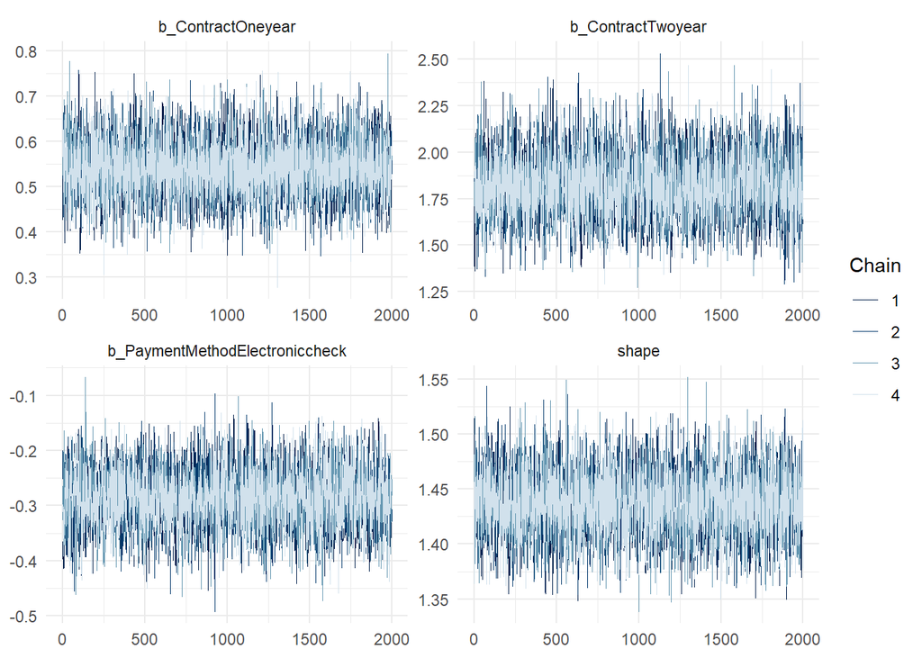

```r
# Trace plots for key parameters
mcmc_trace(bayes_weibull,
           pars = c("b_ContractOneyear", "b_ContractTwoyear",
                   "b_PaymentMethodElectroniccheck", "shape"),
           facet_args = list(ncol = 2))
```

```r
# Extract summary for Rhat values
model_summary <- summary(bayes_weibull)
rhat_vals <- model_summary$fixed$Rhat
cat("All Rhat values < 1.01:", all(rhat_vals < 1.01, na.rm = TRUE), "\n")
```

```
All Rhat values < 1.01: TRUE
```

```r
cat("Max Rhat value:", max(rhat_vals, na.rm = TRUE), "\n")
```

```
Max Rhat value: 1.001479
```

```r
# Effective sample sizes
eff_vals <- model_summary$fixed$Bulk_ESS
cat("Minimum effective sample size:", min(eff_vals, na.rm = TRUE), "\n")
```

```
Minimum effective sample size: 4598.346
```

### 3.5 Posterior Predictive Checks

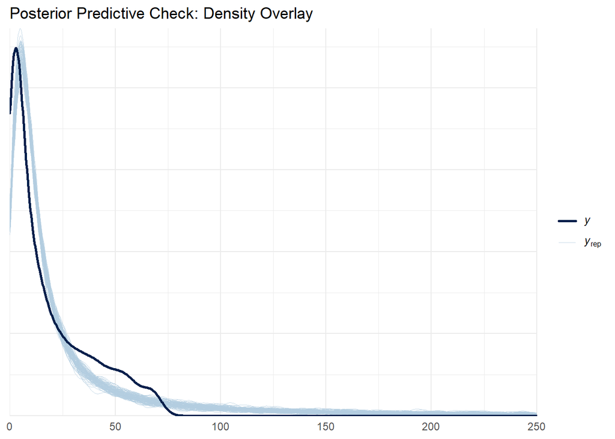

```r
# Density overlay
pp_check(bayes_weibull, type = "dens_overlay", ndraws = 100) +
  labs(title = "Posterior Predictive Check: Density Overlay") +
  xlim(c(0, 250))
```

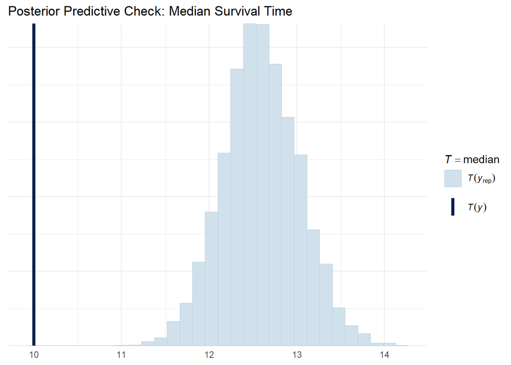

```r
# Survival probability checks at different time points
pp_check(bayes_weibull, type = "stat", stat = "median") +
  labs(title = "Posterior Predictive Check: Median Survival Time")
```

```r
# Check survival probabilities at specific time points
survival_times <- c(12, 24, 36, 48, 60)
pp_survival <- posterior_predict(bayes_weibull, ndraws = 1000)

# Calculate empirical vs predicted survival rates
obs_survival <- sapply(survival_times, function(t) mean(tele_model$time > t))
pred_survival <- sapply(survival_times, function(t) mean(pp_survival > t))

survival_comparison <- data.frame(
  Time = survival_times,
  Observed = obs_survival,
  Predicted = pred_survival,
  Difference = pred_survival - obs_survival
)

survival_comparison %>%
  gt() %>%
  tab_header(title = "Observed vs Predicted Survival Rates") %>%
  fmt_number(columns = c(Observed, Predicted, Difference), decimals = 3)
```

Observed vs Predicted Survival Rates

| Time | Observed | Predicted | Difference |
| --- | --- | --- | --- |
| 12 | 0.690 | 0.771 | 0.081 |
| 24 | 0.544 | 0.649 | 0.105 |
| 36 | 0.425 | 0.578 | 0.153 |
| 48 | 0.316 | 0.529 | 0.213 |
| 60 | 0.198 | 0.493 | 0.295 |

The density overlay plot shows a slight discrepancy between the observed data and the models simulated data. The model under predicts the amount of churning customers with very small times (< 10 months), then over predicts for between 10 and 25 months, and under predicts again for 25 to 75 months before over predicting for any amount of time longer than 75 months. This pattern is reflected in the median survival times where the median of the model predictions is greater than the median of the observed data.

## 4. Results

### 4.1 Parameter Estimates

```r
# Extract posterior summaries
posterior_summary <- as_draws_df(bayes_weibull) %>%
  select(starts_with("b_"), shape) %>%
  pivot_longer(everything(), names_to = "parameter", values_to = "value") %>%
  group_by(parameter) %>%
  summarise(
    mean = mean(value),
    median = median(value),
    sd = sd(value),
    q2.5 = quantile(value, 0.025),
    q97.5 = quantile(value, 0.975),
    prob_positive = mean(value > 0)
  ) %>%
  arrange(desc(abs(mean)))

# Calculate hazard ratios (exp of negative coefficients for Weibull AFT)
hazard_ratios <- posterior_summary %>%
  filter(parameter != "shape") %>%
  mutate(
    HR_mean = exp(-mean),
    HR_q2.5 = exp(-q97.5),
    HR_q97.5 = exp(-q2.5)
  )

# Display results
hazard_ratios %>%
  select(parameter, HR_mean, HR_q2.5, HR_q97.5, prob_positive) %>%
  gt() %>%
  tab_header(title = "Hazard Ratios from Bayesian Model") %>%
  fmt_number(columns = c(HR_mean, HR_q2.5, HR_q97.5), decimals = 3) %>%
  fmt_percent(columns = prob_positive, decimals = 1)
```

Hazard Ratios from Bayesian Model

| parameter | HR_mean | HR_q2.5 | HR_q97.5 | prob_positive |
| --- | --- | --- | --- | --- |
| b_Intercept | 0.011 | 0.010 | 0.013 | 100.0% |
| b_ContractTwoyear | 0.161 | 0.115 | 0.220 | 100.0% |
| b_TotalCharges_scaled | 0.181 | 0.168 | 0.196 | 100.0% |
| b_InternetServiceFiberoptic | 2.355 | 2.171 | 2.556 | 0.0% |
| b_ContractOneyear | 0.582 | 0.513 | 0.658 | 100.0% |
| b_PaymentMethodMailedcheck | 1.336 | 1.185 | 1.511 | 0.0% |
| b_PaymentMethodElectroniccheck | 1.331 | 1.201 | 1.476 | 0.0% |
| b_StreamingTVNointernetservice | 0.808 | 0.146 | 4.551 | 59.6% |
| b_OnlineSecurityNointernetservice | 0.808 | 0.141 | 4.591 | 60.0% |
| b_OnlineSecurityYes | 0.819 | 0.745 | 0.898 | 100.0% |
| b_DeviceProtectionNointernetservice | 0.823 | 0.142 | 4.913 | 58.8% |
| b_StreamingMoviesNointernetservice | 0.824 | 0.148 | 4.777 | 58.9% |
| b_InternetServiceNo | 0.830 | 0.146 | 4.884 | 58.4% |
| b_StreamingTVYes | 1.181 | 1.097 | 1.269 | 0.0% |
| b_StreamingMoviesYes | 1.180 | 1.098 | 1.269 | 0.0% |
| b_PartnerYes | 0.872 | 0.813 | 0.933 | 100.0% |
| b_PaperlessBillingYes | 1.116 | 1.034 | 1.207 | 0.3% |
| b_PaymentMethodCreditcardautomatic | 0.967 | 0.849 | 1.098 | 68.9% |
| b_DeviceProtectionYes | 1.000 | 0.930 | 1.077 | 49.3% |

### 4.2 Visual Comparison of Key Effects

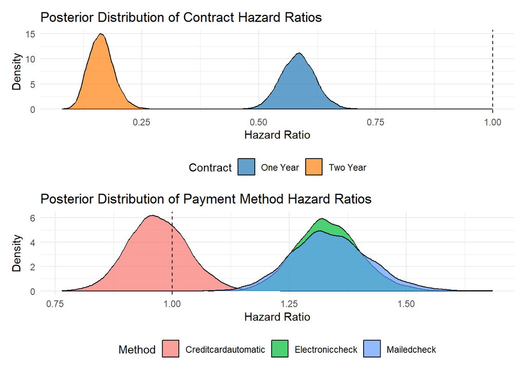

```r
# Extract draws for contract effects
contract_draws <- as_draws_df(bayes_weibull) %>%
  select(b_ContractOneyear, b_ContractTwoyear) %>%
  mutate(
    HR_OneYear = exp(-b_ContractOneyear),
    HR_TwoYear = exp(-b_ContractTwoyear)
  )

# Plot hazard ratios for contracts
p1 <- contract_draws %>%
  select(HR_OneYear, HR_TwoYear) %>%
  pivot_longer(everything(), names_to = "Contract", values_to = "HR") %>%
  ggplot(aes(x = HR, fill = Contract)) +
  geom_density(alpha = 0.7) +
  geom_vline(xintercept = 1, linetype = "dashed") +
  scale_fill_manual(values = c("HR_OneYear" = "#1f77b4", "HR_TwoYear" = "#ff7f0e"),
                    labels = c("One Year", "Two Year")) +
  labs(title = "Posterior Distribution of Contract Hazard Ratios",
       x = "Hazard Ratio", y = "Density") +
  theme(legend.position = "bottom")

# Payment method effects
payment_draws <- as_draws_df(bayes_weibull) %>%
  select(starts_with("b_PaymentMethod")) %>%
  mutate(across(everything(), ~ exp(-.)))

p2 <- payment_draws %>%
  pivot_longer(everything(), names_to = "Method", values_to = "HR") %>%
  mutate(Method = str_remove(Method, "b_PaymentMethod")) %>%
  ggplot(aes(x = HR, fill = Method)) +
  geom_density(alpha = 0.7) +
  geom_vline(xintercept = 1, linetype = "dashed") +
  labs(title = "Posterior Distribution of Payment Method Hazard Ratios",
       x = "Hazard Ratio", y = "Density") +
  theme(legend.position = "bottom")

p1 / p2
```